# lab10

Yixuan Li, UPI:yil845

17 October 2021

### The Data: The source of the data we use in this lab is from Open ML, Phoneme data set.

### Import data

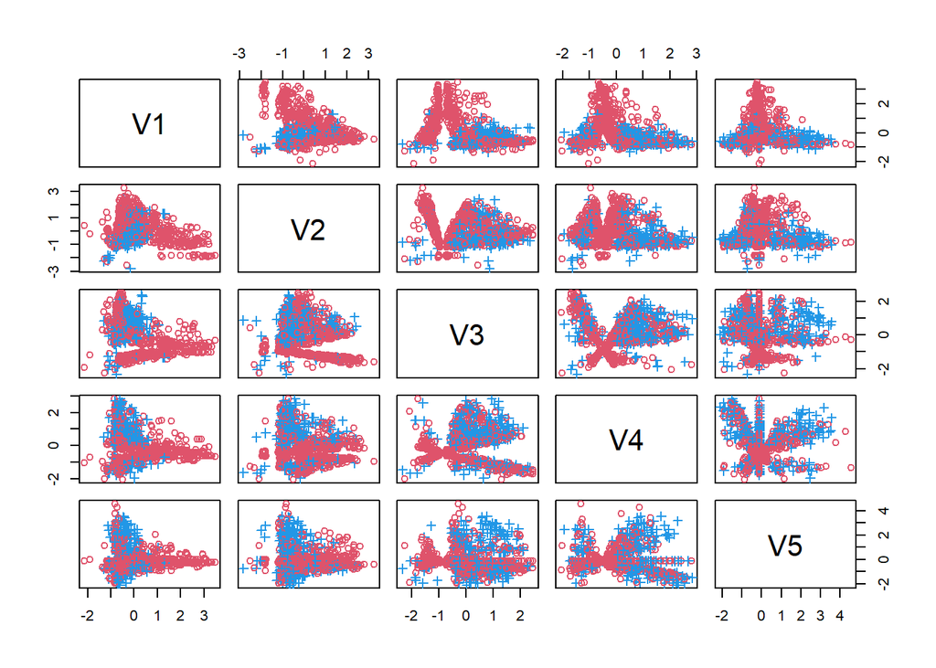

```r
phoneme = read.csv("phoneme.csv", stringsAsFactors=TRUE)
with(phoneme, pairs(phoneme[,-6], col=c(2,4)[Class], pch=c(1,3)[Class]))
```

```r
library(mclust)
knitr::opts_chunk$set(echo = TRUE)
```

### Visualisation

#### 1, The data was sorted according to class label, the majority is in the front, thus is plotted firstly by pairs(), the minority class is plotted secondly, therefore on top.

```r
table(as.numeric(factor(phoneme$Class)))                        ## majority is class 1 -Nasal
```

```
##
##   1   2
## 709 291
```

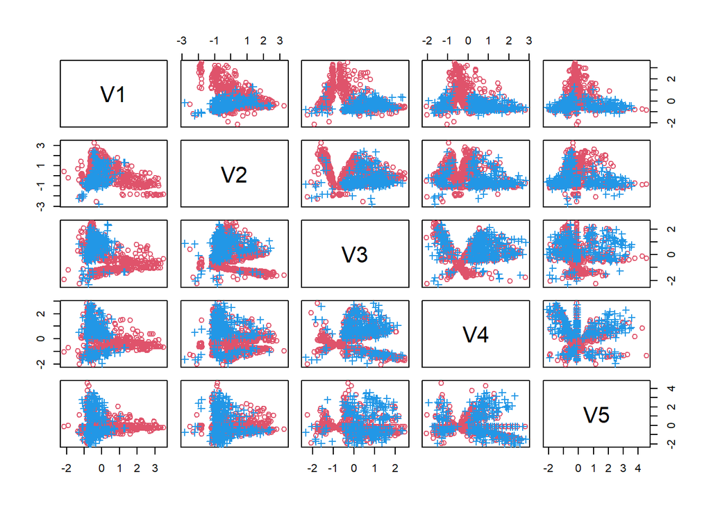

```r
phoneme<- phoneme[order(as.numeric(factor(phoneme$Class))),]    ## sort data with class number of column Class
with(phoneme, pairs(phoneme[,-6], col=c(2,4)[Class], pch=c(1,3)[Class]))
```

### Univariate Density Estimation

#### 2, Plot each of the kernel density estimate, by superimposing it on a histogram (with breaks=100), for V1, with the bandwidth values chosen by methods nrd0, ucv, bcv and SJ, respectively.

#### The nrd0 is underfitting and over-smoothing. Ucv, bcv and SJ methods are all somewhat overtting, esp at high range.

#### from teacher -Overfitting and underfitting can occur in different regions. Let’s take SJ as an example (which is usually considered as a good default bandwidth selector). It is underfitted/oversmoothed around V1 =−1, but at the same time is overfitted/undersmoothed for V1 ≥1, as shown in the next two plots. The reason is that different regions require different bandwidth values for correct smoothing, but KDE uses a common one everywhere.

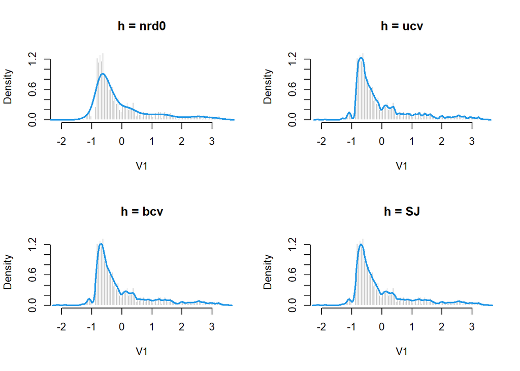

```r
par(mfrow=c(2,2))
for(bw in c("nrd0", "ucv", "bcv", "SJ")) {
   hist(phoneme$V1, freq=FALSE, breaks=100,
        col="gray80", border="white",
        main=paste0("h = ", bw), xlab="V1")
   lines(density(phoneme$V1, bw=bw), col=4, lwd=2)
}
```

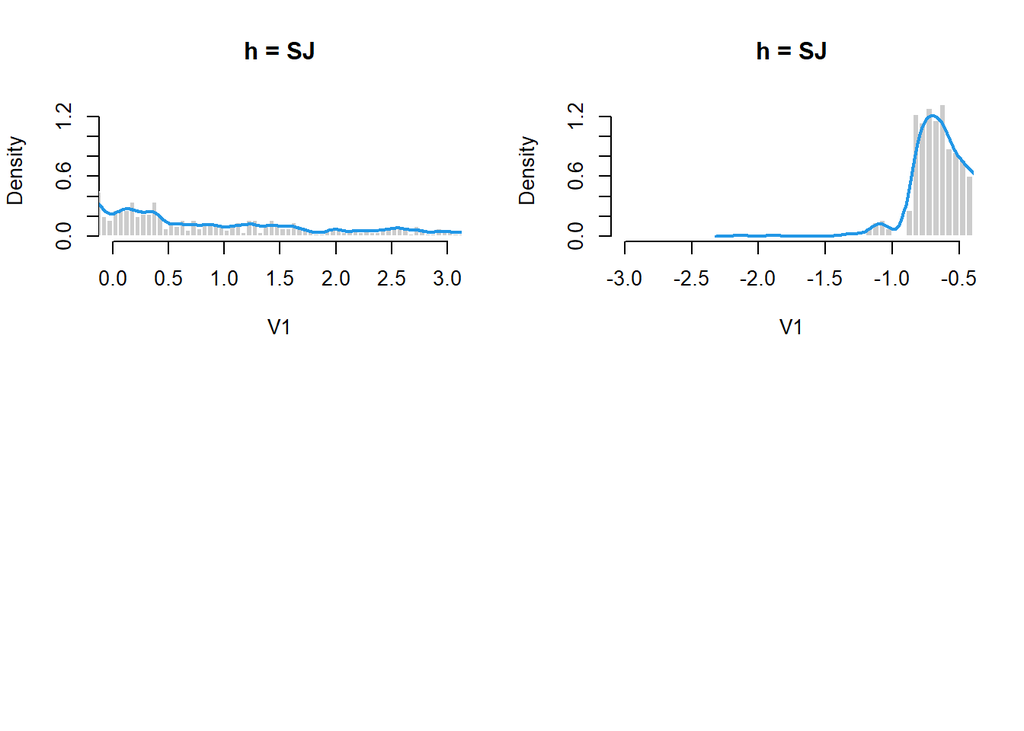

```r
## lower limit
hist(phoneme$V1, freq=FALSE, breaks=100,
        col="gray80", border="white",
        main=paste0("h = ", "SJ"),xlim=c(0,3), xlab="V1")
   lines(density(phoneme$V1, bw="SJ"), col=4, lwd=2)
##upper limit
hist(phoneme$V1, freq=FALSE, breaks=100,
        col="gray80", border="white",
        main=paste0("h = ", "SJ"),xlim=c(-3,-0.5), xlab="V1")
   lines(density(phoneme$V1, bw="SJ"), col=4, lwd=2)
```

#### 3, Find BIC selected the best normal mixture fit to V1 in both equal and varying variance subfamilies, with the number of components ranging from 1 to 20.Plot the fitted density, along with a histogram of the data.

#### BIC values of varying variance is bigger than that of equal variance density estimates,indicating varying variance fitting is better. The plot looks well-fitted, better than the results of KDEs.(teacher)It has much less underfitting or overfitting and is a better fit than any of the above KDEs, as can also be seen in the plots below. This is because a mixture with varying variances is more adaptive to the data everywhere.

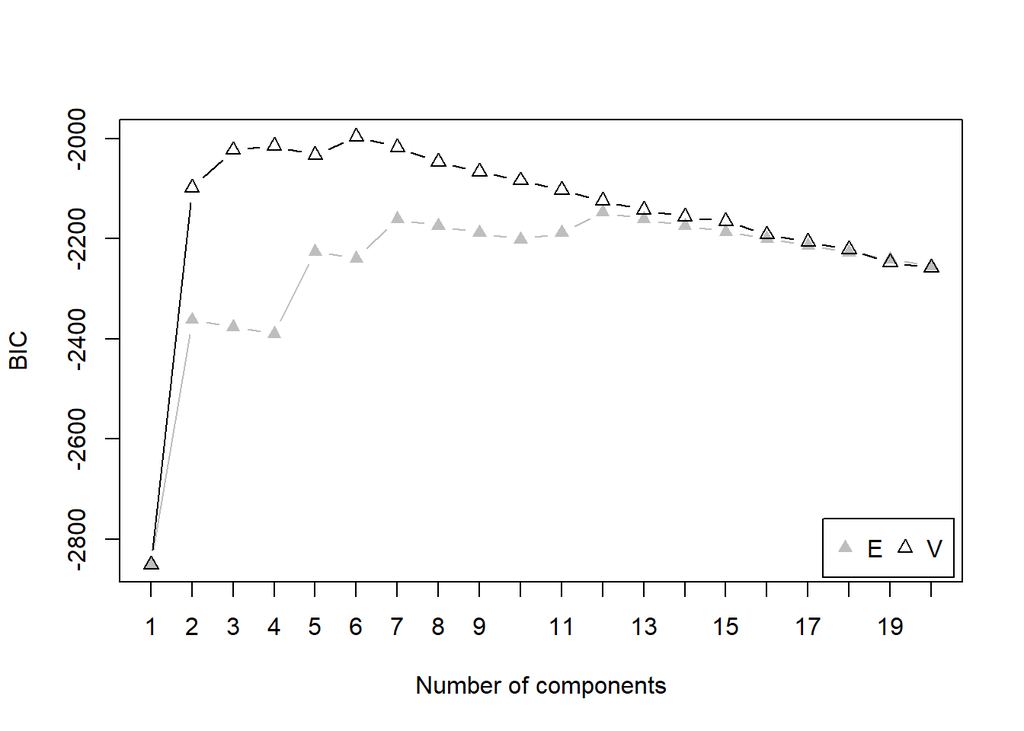

```r
r<-densityMclust(phoneme$V1,G=1:20)
#r$parameters
plot(r, what="BIC")
```

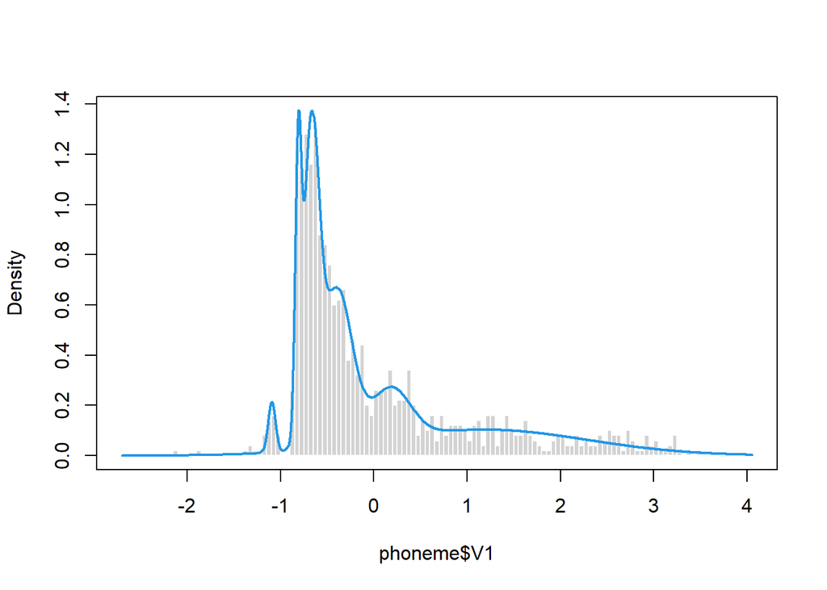

```r
### the fitted density with 6 components - maximum BIC for model Varying variance
r6 = densityMclust(phoneme$V1, G=6, modelNames="V")  # 6 components, varying variance
plot(r6, phoneme$V1, "density", breaks=100, lwd=2, col=4)
```

### Multivariate density estimation

#### 4, For each of the two classes, find a density estimate in the equal variance (EEE)subfamily of multivariate normal mixtures, with the number of components ranging from 1 to 9. Pairwise plot of estimated density with data are plotted.

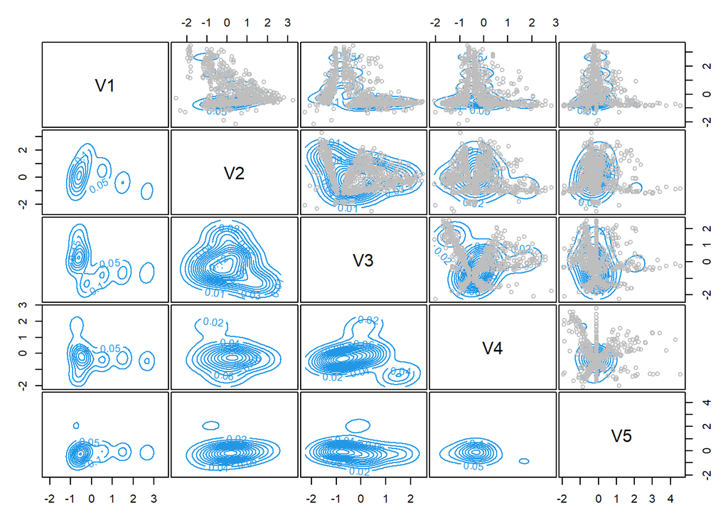

```r
## subset data into oral and nasal
oral<- phoneme[phoneme$Class=="Oral",]
nasal<- phoneme[phoneme$Class=="Nasal",]

## estimated EEE density for oral and nasal
r.eoral<-densityMclust(oral[,-6],G=1:9 ,modelNames="EEE")
r.enasal<-densityMclust(nasal[,-6],G=1:9 ,modelNames="EEE")

## pairwise plot of estimated density of Nasal & Oral with method "EEE"
plot(r.enasal,nasal[,-6],what="density",col=4, points.col="grey")
```

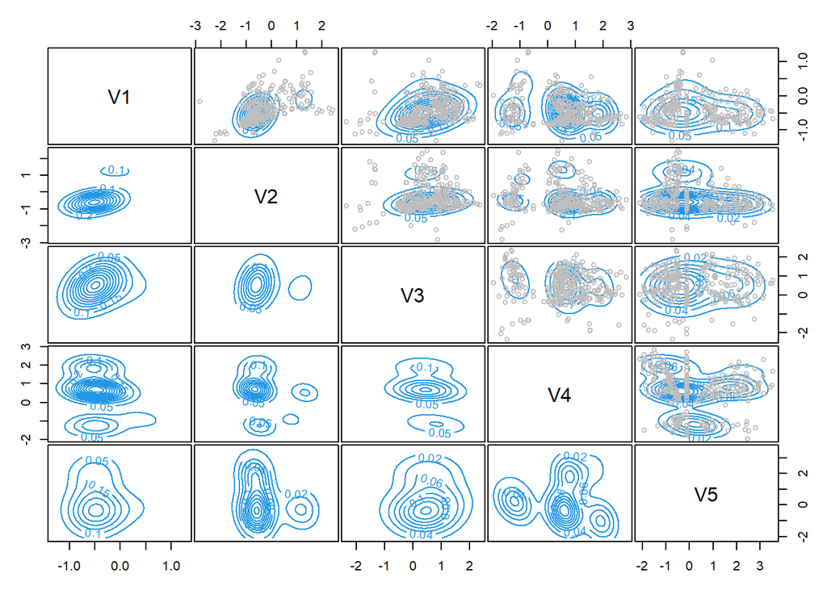

```r
plot(r.eoral,oral[,-6],what="density",col=4, points.col="grey")
```

#### 5, Repeat Task 4, but for the varying variance subfamily of normal mixtures.

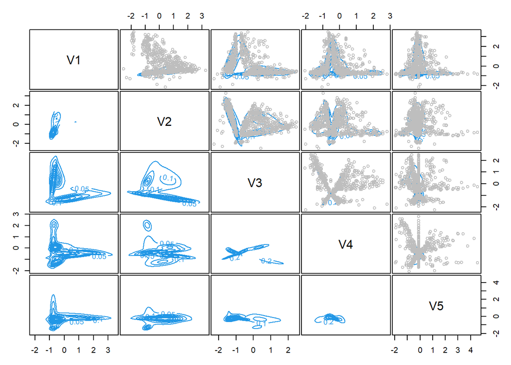

```r
## estimated VVV density for oral and nasal
r.voral<-densityMclust(oral[,-6],G=1:9 ,modelNames="VVV")
r.vnasal<-densityMclust(nasal[,-6],G=1:9 ,modelNames="VVV")
## pairwise plot of density of Nasal & Oral with method "VVV"
plot(r.vnasal,nasal[,-6],what="density",col=4, points.col="grey")
```

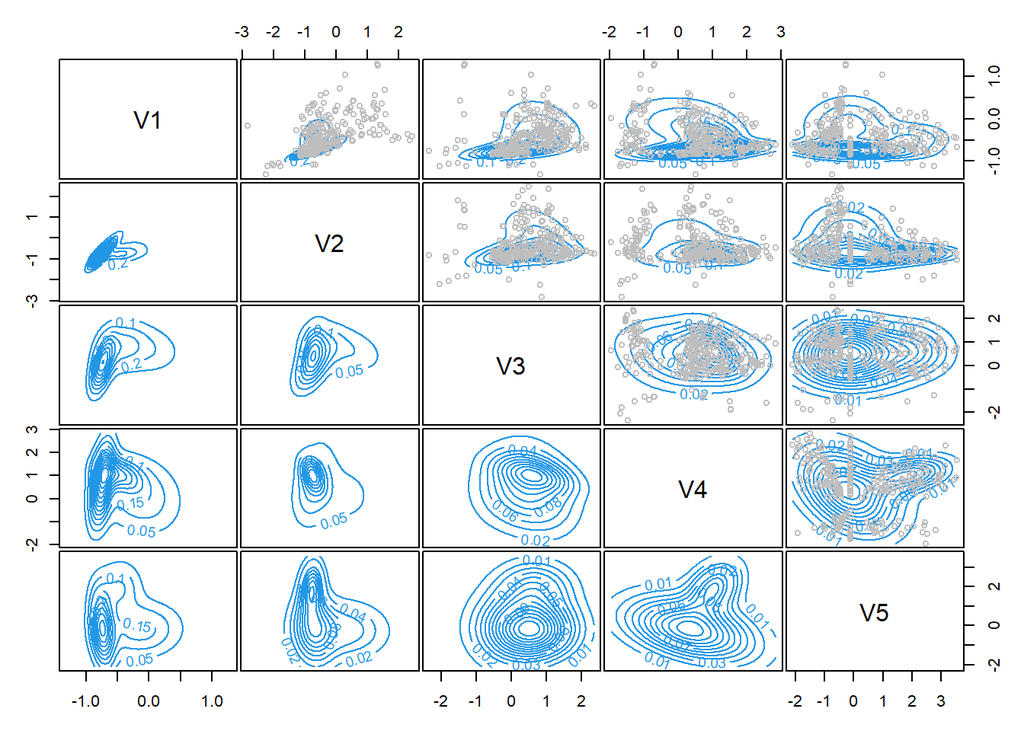

```r
plot(r.voral,oral[,-6],what="density",col=4, points.col="grey")
```

#### 6, By applying the fundamental rule of classification, we multiply the prior probability of each class with predicted posterior probability of each class, and compared them to get the number of classification. we compare this classification with the column “Class” in phoneme and calculate the misclassification rate for both model “EEE” & “VVV”.

#### the misclassification rate for method “EEE” is 18%; 16.5 for method “VVV”.

```r
prior.p<-prop.table(table(phoneme$Class))            ## prior probability of oral & Nasal in phoneme
## EEE model
p.eoral<-predict(r.eoral,phoneme[,1:5])*prior.p[2]   ## posterior probability of Oral (EEE)
p.enasal<-predict(r.enasal,phoneme[,1:5])*prior.p[1] ## posterior probability of Nasal (EEE)
t.e<- ifelse(p.eoral>p.enasal,2,1)

## misclassification rate of model EEE
mean(t.e!=as.numeric(factor(phoneme[,6])))
```

```
## [1] 0.18
```

```r
## VVV model
p.voral<-predict(r.voral,phoneme[,1:5])*prior.p[2]   ## posterior probability of Oral (VVV)
p.vnasal<-predict(r.vnasal,phoneme[,1:5])*prior.p[1] ## posterior probability of Nasal (VVV)
t.v<- ifelse(p.voral>p.vnasal,2,1)

## misclassification rate of model VVV
mean(t.v!=as.numeric(factor(phoneme[,6])))
```

```
## [1] 0.165
```

#### all data estimation with both VVV & EEE

```r
### test with whole data phoneme for both model "EEE" and "VVV"
r.all<-densityMclust(phoneme[,-6],G=1:9 ,modelNames=c("VVV","EEE"))
#(r.all$parameters), model with 9 components has highest BIC
p.all<-ifelse(predict(r.all,phoneme[,-6])>0.5,2,1)
#misclassification rate of whole dataset phoneme ~34%, larger error
mean(p.all!=as.numeric(factor(phoneme[,6])))
```

```
## [1] 0.337
```

### K-means

#### 7, With the K-means method, find the clustering results with two clusters. Show the results in a pairwise plot of the data, using different colors and point types for observations of different clusters.

#### The majority of class (Nasal) was plotted firstly as red triangles, then the class (Oral) in blue crosses. The center of clusters is in either black (Nasal) or green (oral). Hardly any centers (black/green) can be seen, indicating poor clustering.

```r
## with two clusters
set.seed(432)
(r0 = kmeans(phoneme[,-6], centers=2)) # K = 2
```

[output not shown]

[output cut: 128 more lines]

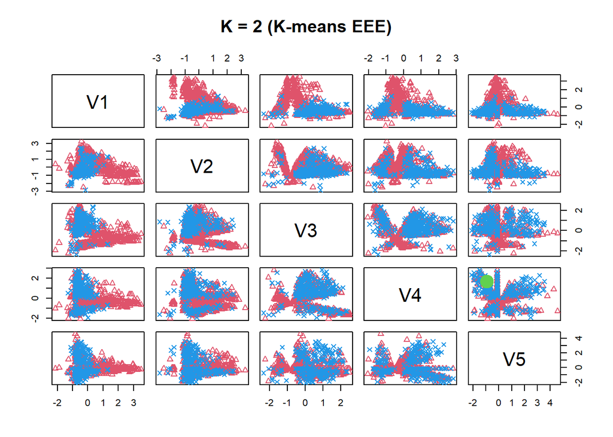

```r
#o = order.majority(r0$cluster)
#(count1 = attr(o, "count.majority"))
with(phoneme, pairs(phoneme[,-6], col=c(2,4)[Class],pch=c(2,4)[Class], main="K = 2 (K-means EEE)"))
points(r0$centers, col=c(1,3), pch=19, cex=2)
```

#### 8, Compare the results obtained with K means clustering (unsupervised clustering) with the availalbe class in phoneme dataset.

```r
accuracy = double(8)

for(k in 2:9) {
  set.seed(432)
  r = kmeans(phoneme[,-6], centers=k)
  accuracy[k-1]<- adjustedRandIndex(r$cluster,as.numeric(factor(phoneme$Class)))
}
## clustering accuracy
accuracy
```

```
## [1] 0.08058490 0.12999026 0.06678252 0.09069357 0.06855240 0.05386771 0.04999859
## [8] 0.03767955
```

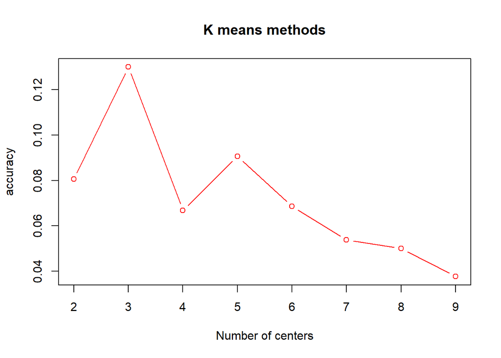

```r
plot(2:9,accuracy, type="b",col="red", xlab="Number of centers",ylab="accuracy", main="K means methods")
```

### Mixture-based clustering

#### 9, Use the varying variance subfamily of multivariate normal mixtures to find the clustering results with two clusters, and show the results in a pairwise plot,compute the adjusted Rand indices for K=2,…9 clusters.

#### The classification accuracy is almost 0, indicating no similarity of mixture based clustering comparing to original class.

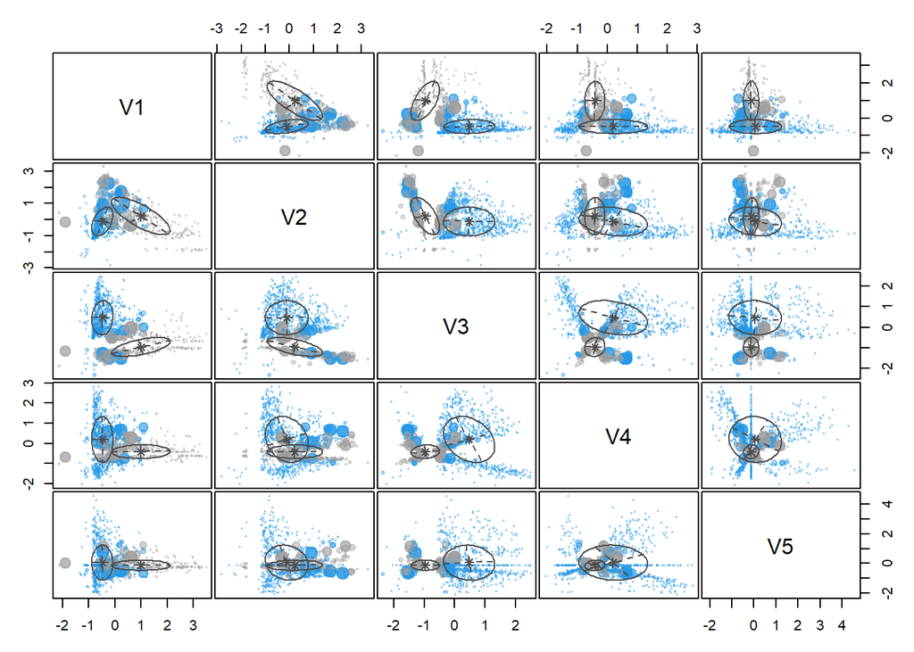

```r
set.seed(432)
r.mbc = Mclust(phoneme[,-6], G=2, modelNames="VVV")

plot(r.mbc,"uncertainty",col=c(8,4), main="K = 2 (k-means, VVV)")  ## uncertainty plot of varying variance method with 2 centers
```

```r
### compute clustering accuracy for k = 2~9
accuracy.v = double(8)
for(k in 2:9) {
  r.mbc = Mclust(phoneme[,-6], G=k, modelNames = "VVV")
  accuracy.v[k-1]<- adjustedRandIndex(r.mbc$classification, as.numeric(factor(phoneme$Class)))
}

## clustering accuracy
accuracy.v
```

```
## [1] 0.02963741 0.05014537 0.07091669 0.05169660 0.03648900 0.03973215 0.03236527
## [8] 0.03569147
```

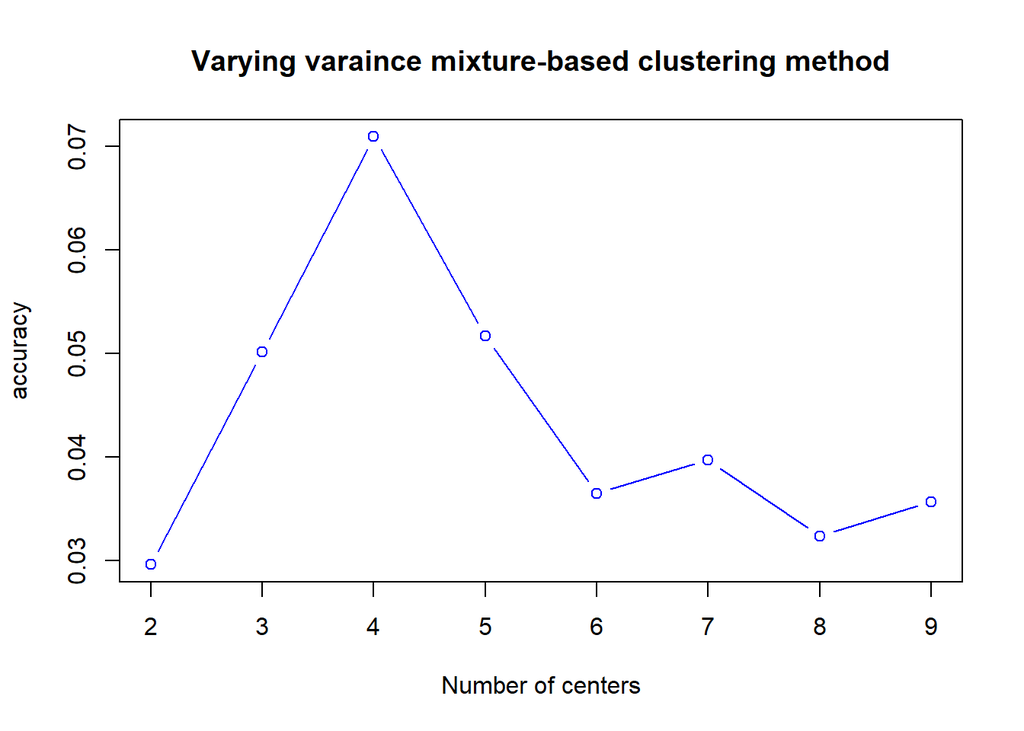

```r
plot(2:9,accuracy.v,type="b",col="blue", xlab="Number of centers",ylab="accuracy", main="Varying varaince mixture-based clustering method")
```

### Hierarchical Clustering

#### 10,Produce a dendrogram of the hierarchical clustering results using the complete and the single linkage method, respectively.

#### Explain why they look very much different? Complete linkage clustering maximizes the pairwise observations’ dissimilarity, while single linkage clustering minimizes the dissimilarity. For this dataset, there is no clear boundary between different clusters, thus by comparing euclidean distance of pairwised observations is not sufficient for clustering.

## (from teacher)The complete-linkage method tends to produce more compact clusters and relatively large clusters near the top of the clustering tree.With the single-linkage method, clusters are linked purely based on two closest observations and may exhibit an extended, chain shape. It thus tends to produce clusters with very few observations even near the top of the clustering tree.

```r
## standardize phoneme - euclidean distance matrix
phoneme3<-dist(phoneme[,-6])
## complete linkage
r.cl = hclust(phoneme3)                # complete linkage by default
names(r.cl)
```

```
## [1] "merge"       "height"      "order"       "labels"      "method"
## [6] "call"        "dist.method"
```

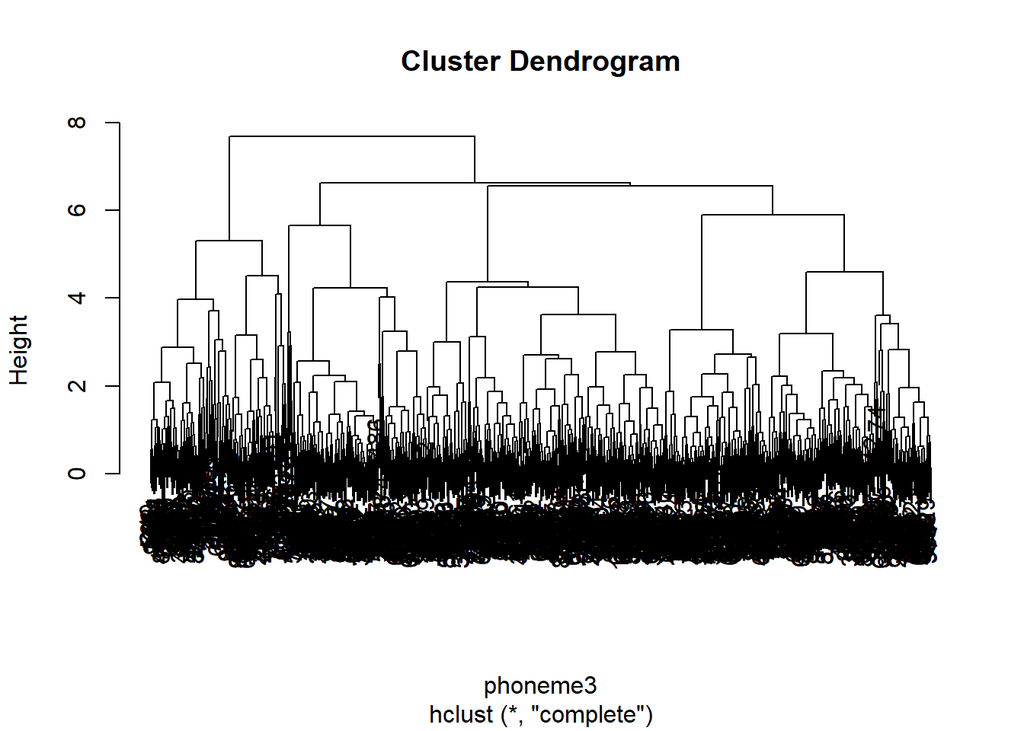

```r
plot(r.cl)
```

```r
## single linkage
r.sl= hclust(phoneme3,method="single")

names(r.sl)
```

```
## [1] "merge"       "height"      "order"       "labels"      "method"
## [6] "call"        "dist.method"
```

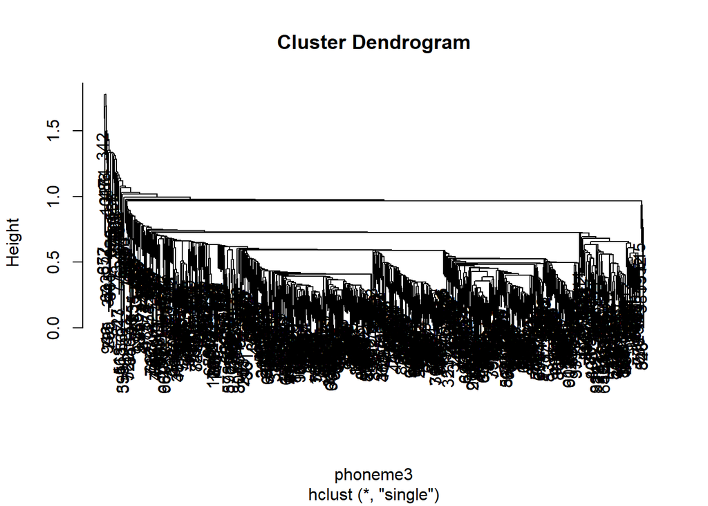

```r
plot(r.sl)
```

#### 11, Compute the adjusted Rand indices for K=2,…,9 clusters produced by the complete and the single linkage method, respectively.

#### The result shows very low ARI values, close to 0, which means both tree clustering methods of complete and single linkage methods are not consistent, indicating data can not be seperable with pairwise euclidean distances dissimilarity.

```r
### compute ari
ari = double(9)
for(k in 2:9) {
  r.cl = hclust(phoneme3)
  ari[k-1] = adjustedRandIndex(cutree(r.cl,k), cutree(r.sl,k))
}
ari
```

```
## [1] -0.0015711706  0.0033555333  0.0002705179  0.0006832815  0.0017865693
## [6]  0.0019591100  0.0051464297  0.0080570515  0.0000000000
```

```r
## For the complete-linkage method, the 2-cluster partition is a little bit similar to that according to class labels, as ARI =0.152.

## For the single-linkage method, all ARI-values are virtually 0, indicating no similarity between any of its clustering partitions and the one according to class labels.
round(sapply(1:8, function(j) adjustedRandIndex(phoneme[,6], cutree(r.cl,j+1))), 3)
```

```
## [1] 0.152 0.087 0.048 0.069 0.070 0.075 0.081 0.082
```

```r
round(sapply(1:8, function(j) adjustedRandIndex(phoneme[,6], cutree(r.sl,j+1))), 3)
```

```
## [1] -0.001  0.001 -0.001  0.002  0.005  0.004  0.008  0.014
```

#### 12, Produce the heatmaps for both the complete and single linkage methods.High values are in red, low values are in yellow.

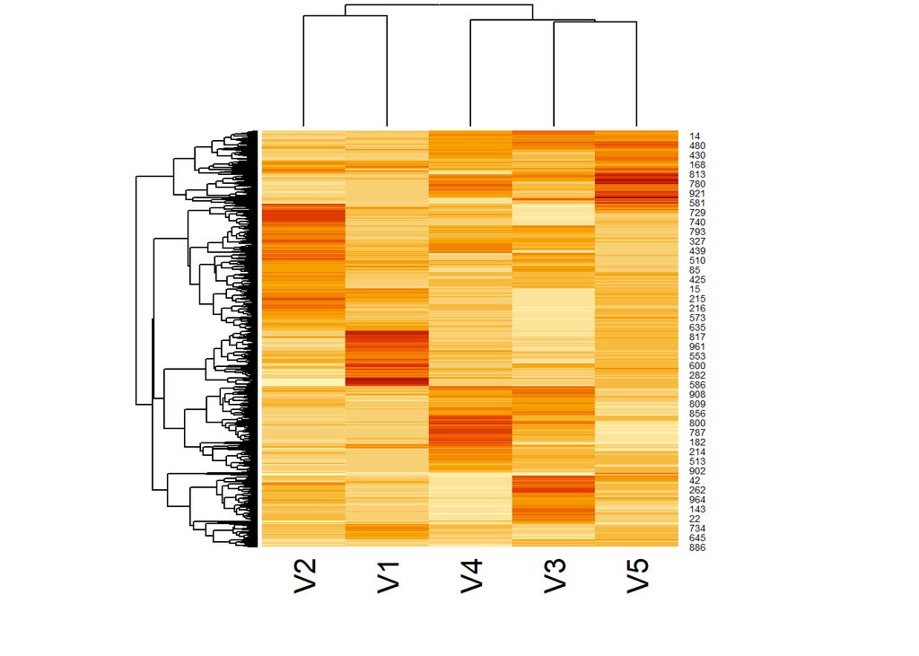

```r
## complete linkage
heatmap(as.matrix(phoneme[,-6]), scale="column", distfun=dist, hclustfun=hclust)
```

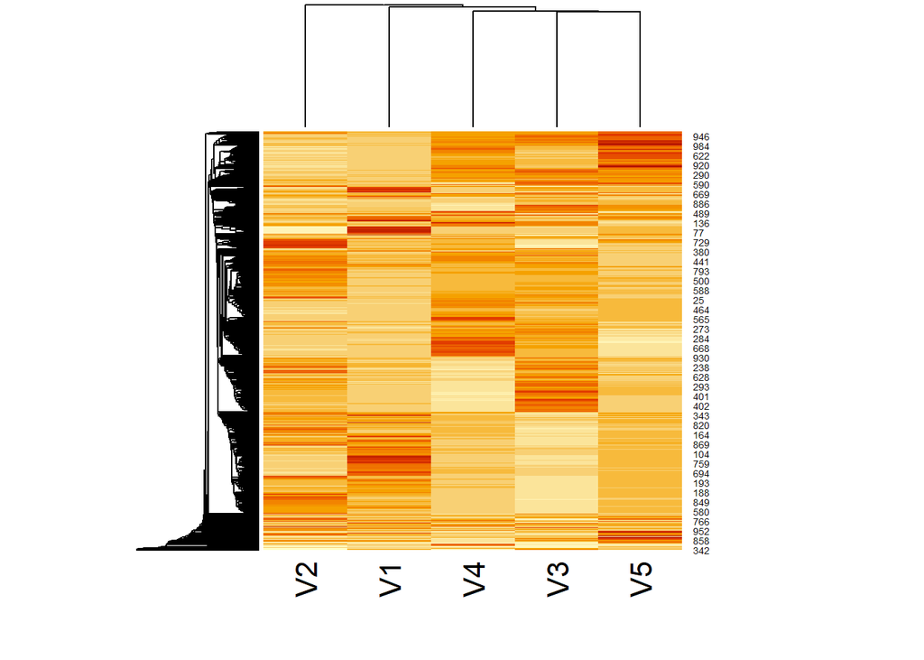

```r
## single linkage
hclust.single<- function(x, ...) hclust(x, method="single", ...)
heatmap(as.matrix(phoneme[,-6]), scale="none", distfun=dist, hclustfun=hclust.single)
```